# Coursework Report

*N* removed NAs: 3

*N* removed typo: 1

*N* removed <18: 24

[output not shown]

**Main analysis results**

[interactive chart not shown]

[figure not shown]

[interactive chart not shown]

# Coursework Report

Analysing Data, Spring 2020

[output not shown]

[output not shown]

```
## [1] 3
```

```
## .
## 10 13 14 15 16 17 18 19 20 21 22 23 24 25 26  7
##  1  1  1  2  5 13 21 15 16 18 23 16  7  5  2  1
```

```
## [1] "numeric"
```

```
## .
##      control experimental
##           72           75
```

```
## tibble [147 x 6] (S3: tbl_df/tbl/data.frame)
##  $ id_code: Factor w/ 150 levels "ADNT","AHKQ",..: 95 33 123 18 2 118 125 61 127 115 ...
##  $ age    : num [1:147] 17 26 17 17 15 20 22 25 20 24 ...
##  $ group  : Factor w/ 2 levels "control","experimental": 1 1 1 1 1 1 1 1 1 1 ...
##  $ item_1 : num [1:147] 7 7 6 6 7 8 7 6 5 6 ...
##  $ item_2 : num [1:147] 4 4 6 6 5 8 8 6 7 7 ...
##  $ item_3 : num [1:147] 4 6 6 7 6 8 6 4 8 8 ...
```

```
## [1] 24
```

```
## # A tibble: 1 x 4
##    mean    sd   min   max
##   <dbl> <dbl> <dbl> <dbl>
## 1  21.0  2.11    18    26
```

```
## # A tibble: 1 x 4
##    mean    sd   min   max
##   <dbl> <dbl> <dbl> <dbl>
## 1  21.0  2.11    18    26
```

| group | n | perc | mean_age | sd_age |
| --- | --- | --- | --- | --- |
| control | 61 | 49.5935 | 21.09836 | 2.030640 |
| experimental | 62 | 50.4065 | 20.85484 | 2.201689 |

Table 1 *Descriptive statistics by Colour Group*

| Colour Group | *N* | % | *M*<sub>age</sub> | *SD*<sub>age</sub> |
| --- | --- | --- | --- | --- |
| control | 61 | 49.59 | 21.10 | 2.03 |
| experimental | 62 | 50.41 | 20.85 | 2.20 |

```
## # A tibble: 123 x 5
##    id_code item_1 item_2 item_3 attract_comp
##    <fct>    <dbl>  <dbl>  <dbl>        <dbl>
##  1 EKVT         7      4      6         6.08
##  2 THLK         8      8      8         6.08
##  3 UOGA         7      8      6         6.08
##  4 IWUK         6      6      4         6.08
##  5 UUIM         5      7      8         6.08
##  6 SMVK         6      7      8         6.08
##  7 XWYQ         8      7      8         6.08
##  8 IGIY         6      7      8         6.08
##  9 BKIX         6      5      6         6.08
## 10 GXJO         6      6      6         6.08
## # ... with 113 more rows
```

```
## # A tibble: 123 x 5
##    id_code item_1 item_2 item_3 attract_comp
##    <fct>    <dbl>  <dbl>  <dbl>        <dbl>
##  1 EKVT         7      4      6         6.08
##  2 THLK         8      8      8         6.08
##  3 UOGA         7      8      6         6.08
##  4 IWUK         6      6      4         6.08
##  5 UUIM         5      7      8         6.08
##  6 SMVK         6      7      8         6.08
##  7 XWYQ         8      7      8         6.08
##  8 IGIY         6      7      8         6.08
##  9 BKIX         6      5      6         6.08
## 10 GXJO         6      6      6         6.08
## # ... with 113 more rows
```

```
## # A tibble: 123 x 5
## # Groups:   id_code [123]
##    id_code item_1 item_2 item_3 attract_comp
##    <fct>    <dbl>  <dbl>  <dbl>        <dbl>
##  1 EKVT         7      4      6         5.67
##  2 THLK         8      8      8         8
##  3 UOGA         7      8      6         7
##  4 IWUK         6      6      4         5.33
##  5 UUIM         5      7      8         6.67
##  6 SMVK         6      7      8         7
##  7 XWYQ         8      7      8         7.67
##  8 IGIY         6      7      8         7
##  9 BKIX         6      5      6         5.67
## 10 GXJO         6      6      6         6
## # ... with 113 more rows
```

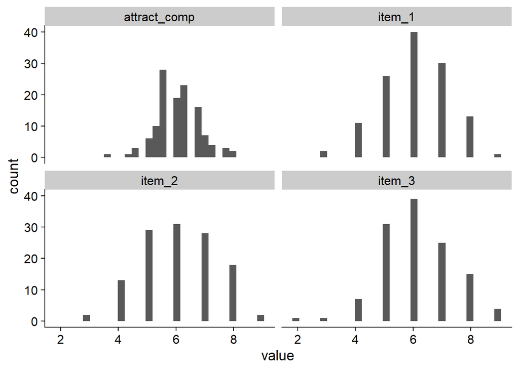

```
##
##  Pearson's product-moment correlation
##
## data:  data$item_1 and data$item_2
## t = -0.97508, df = 121, p-value = 0.3315
## alternative hypothesis: true correlation is not equal to 0
## 95 percent confidence interval:
##  -0.26124773  0.09014638
## sample estimates:
##        cor
## -0.0882971
```

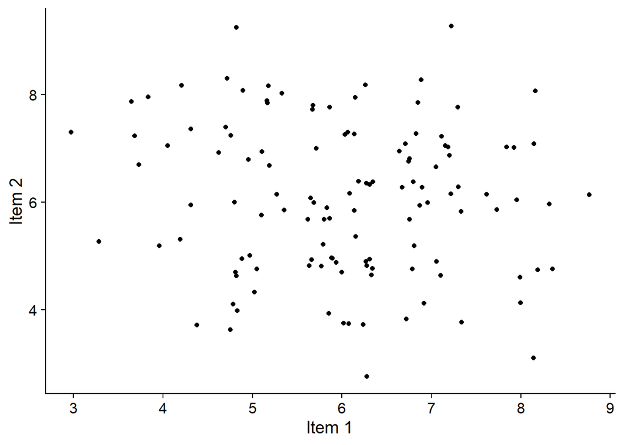

```
##        item_1 item_2 item_3
## item_1   1.00  -0.09   0.05
## item_2  -0.09   1.00   0.03
## item_3   0.05   0.03   1.00
##
## n= 123
##
##
## P
##        item_1 item_2 item_3
## item_1        0.3315 0.5493
## item_2 0.3315        0.7177
## item_3 0.5493 0.7177
```

[figure not shown]

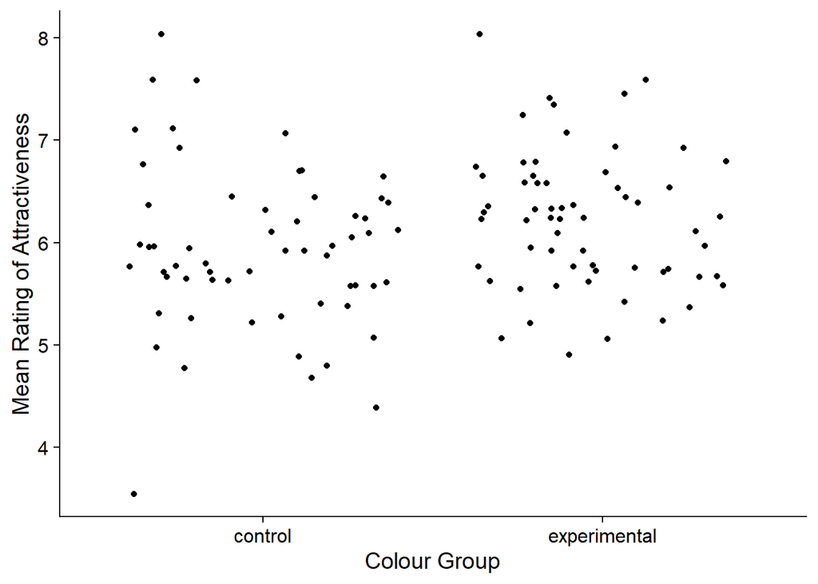

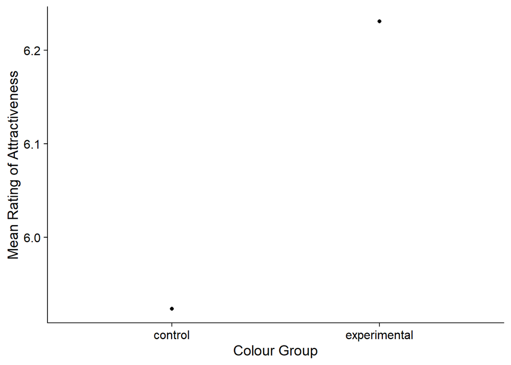

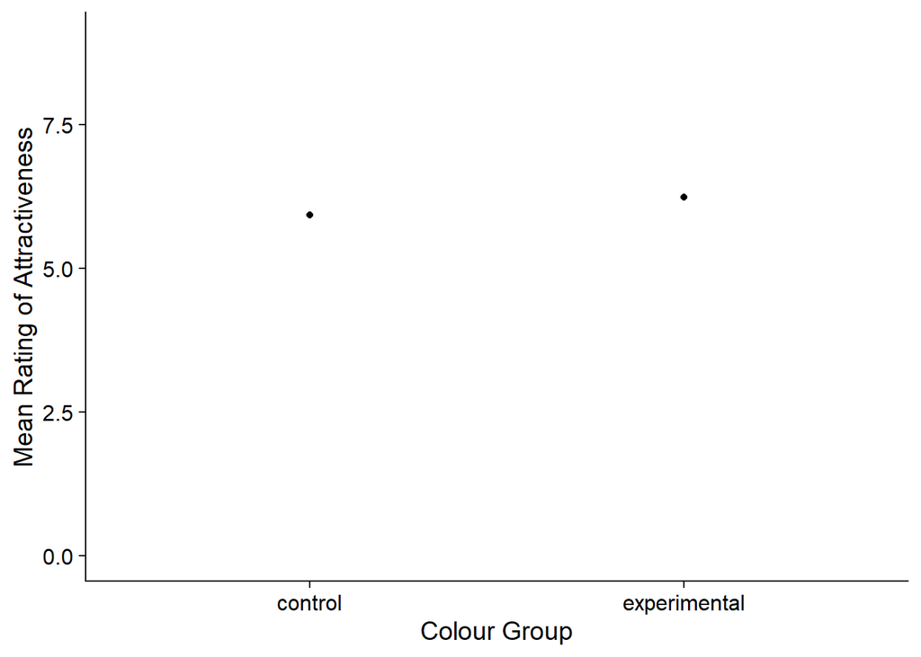

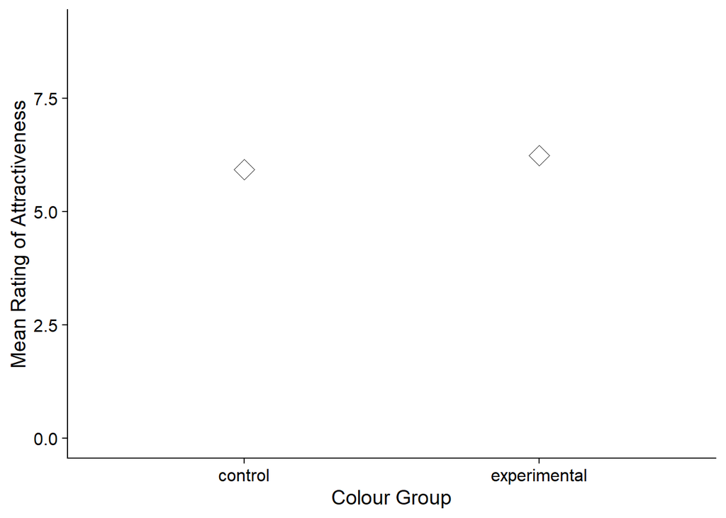

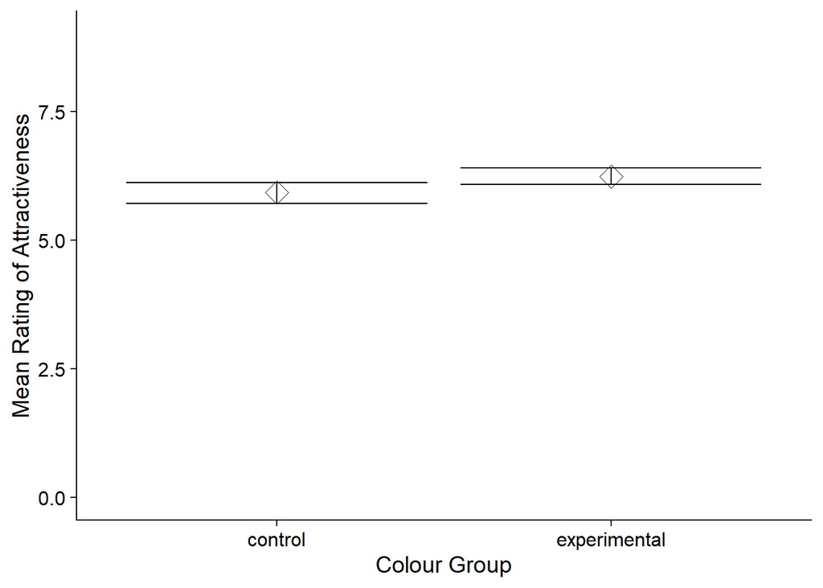

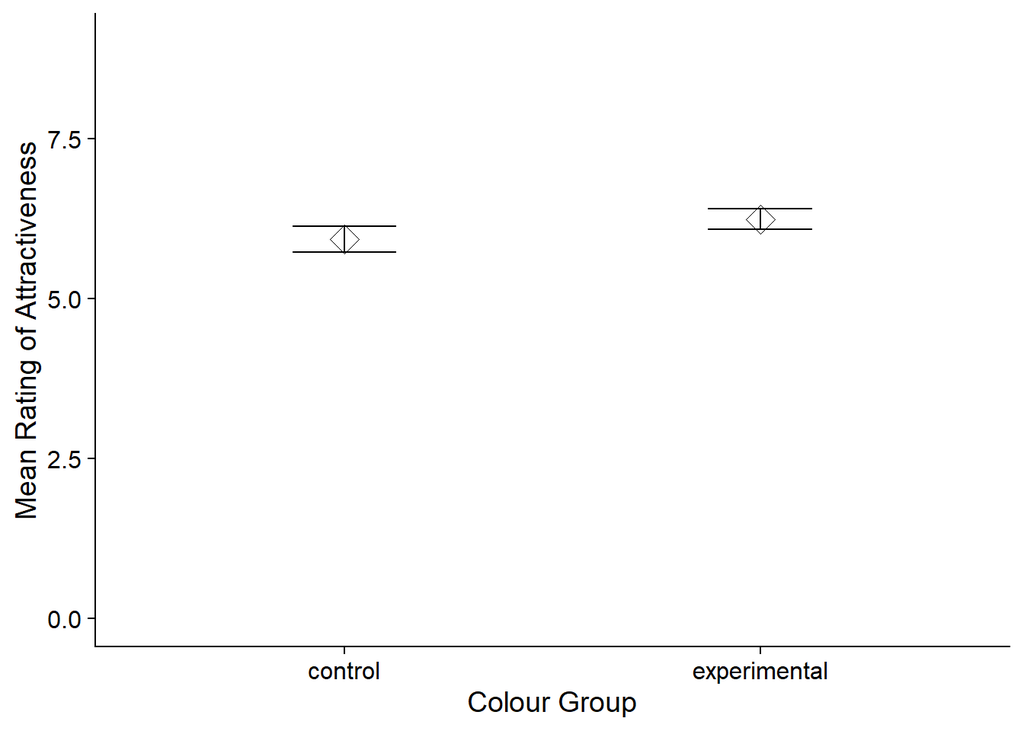

```
##
##  Two Sample t-test
##
## data:  item_1 by group
## t = -1.2663, df = 121, p-value = 0.2078
## alternative hypothesis: true difference in means is not equal to 0
## 95 percent confidence interval:
##  -0.706935  0.155375
## sample estimates:
##      mean in group control mean in group experimental
##                   5.901639                   6.177419
```

# Methods

## Participants

Initially 150 people participated in the experiment, however when cleaning my data I removed 3 participants who provided N/A for their age as this removed insufficient data. I then removed a further 24 participants who were under the age of 18 to abide by ethical guidelines as children cannot provide legal consent. Therefore, data from a total of 123 participants was included in my results. The mean age of the participants was 20.98. The standard deviation of the participants age was 2.11. The maximum age of participants is 26 and the minimum age of participants was 18 creating an age range of 8 years.

Table 1 *Descriptive statistics by Colour Group*

| Group | *N* | % | *M*<sub>age</sub> | *SD*<sub>age</sub> |
| --- | --- | --- | --- | --- |
| control | 61 | 49.59 | 21.10 | 2.03 |
| experimental | 62 | 50.41 | 20.85 | 2.20 |

## Design

The conceptual hypothesis of this study was: Does colour influence attractiveness? The independent categorical variable in this study was colour, which was operationalised on 2 levels of coloured frames (red or white). This study had a between- subjects design and colour was the predictor, in the control group participants saw a picture in a white frame whereas in the experimental group, participants saw a picture in a red frame. Attractiveness was the continuous, dependent variable, which was measured on a 9 point Likert scale (higher rating = more attractive) for each of the following items: Item 1, how attractive do you think this person is? Item 2, How pleasant is this person to look at? Item 3, If I were to meet the person in this picture face to face, I would think he is attractive. The rated attractiveness for each item was the outcome of the study. The answers from each item were averaged to create a composite score of overall rating of attractiveness for each participant. The operational hypothesis for the study is: Does viewing an image of a moderately attractive man in a different colour frame influence the mean rating of his attractiveness? The statistical analysis used to test this hypothesis was a t-test.

# Results

```
## # A tibble: 1 x 4
##    mean    sd   min   max
##   <dbl> <dbl> <dbl> <dbl>
## 1  6.08  0.74  3.67     8
```

```
## # A tibble: 1 x 4
##    mean    sd   min   max
##   <dbl> <dbl> <dbl> <dbl>
## 1  6.08  0.74  3.67     8
```

| group | n | perc | mean_attract_comp | sd_attract_comp |
| --- | --- | --- | --- | --- |
| control | 61 | 49.5935 | 5.923497 | 0.7826674 |
| experimental | 62 | 50.4065 | 6.231183 | 0.6627995 |

Table 1 *Descriptive statistics of Attractiveness by Colour Group*

| Colour Group | *N* | % | *M*<sub>attractiveness</sub> | *SD*<sub>attractiveness</sub> |
| --- | --- | --- | --- | --- |
| control | 61 | 49.59 | 5.92 | 0.78 |
| experimental | 62 | 50.41 | 6.23 | 0.66 |

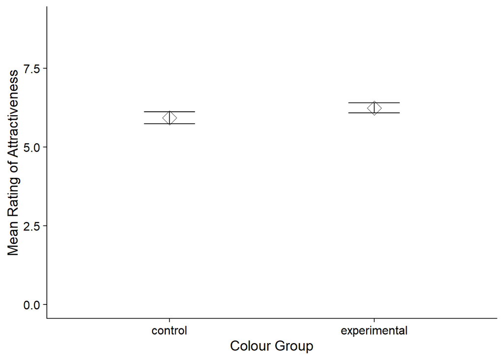